# Homework 9

Kyle Dittmer

3/21/2018

1. Use the code that you worked on in the last exercise, and re-organize it following the principles of structured programming. Do all the work in a single chunk in your R markdown file, just as if you were writing a single R script. Start with all of your annotated functions, preliminary calls, and global variables. The program body should be only a few lines of code that call the appropriate functions and run them in the correct order. Make sure that the output from one function serves as the input to the next. You can either daisy-chain the functions or write separate lines of code to hold elements in temporary variables and pass the along.

```r
library(ggplot2)
library(reshape2)

########################################################
# FUNCTION: dataCreate
# compares expected (not observed) data between no till (NT) and conventional till (CT) assuming a normal distribution for each
# input: numeric and categorical (i.e., yield in tons/acre and NT versus CT)
# output: data frame called DataFun
#-------------------------------------------------------
dataCreate <- function(n1=50,m1=30,sd1=4,n2=50,m2=20,sd2=5){
  NTyield <- rnorm(n=n1, mean=m1, sd=sd1)
  CTyield <- rnorm(n=n2, mean=m2, sd=sd2)
  data1 <- data.frame(NTyield,CTyield)
  data2 <- melt(data1) # need to "melt" data1 in order to change the "variable" column to categorical data to perform an anova (comparing categorical data to continious data)
  return(data2)
}
dataCreate() # checking the function
```

```
##     variable     value
## 1    NTyield 32.420086
## 2    NTyield 21.221694
## 3    NTyield 26.516282
## 4    NTyield 30.616031
## 5    NTyield 33.251826
## 6    NTyield 28.611469
## 7    NTyield 30.551463
## 8    NTyield 25.056668
## 9    NTyield 22.494498
## 10   NTyield 27.590209
## 11   NTyield 27.931597
## 12   NTyield 39.153258
## 13   NTyield 24.626557
## 14   NTyield 28.047590
```

[output cut: 86 more lines]

```r
DataFun <- dataCreate() # changing the function to a data frame by renaming it
str(DataFun)
```

```
## 'data.frame':    100 obs. of  2 variables:
##  $ variable: Factor w/ 2 levels "NTyield","CTyield": 1 1 1 1 1 1 1 1 1 1 ...
##  $ value   : num  25.8 25.9 30.5 29.9 25.9 ...
```

```r
########################################################
# FUNCTION: ANOfun
# runs an anova on the data created from the previous function
# input: DataFun (created in previous function)
# output: p-values
#-------------------------------------------------------
ANOfun <- function(data=DataFun){
  ANOanalysis <- aov(value~variable,data=data)
  summary(ANOanalysis)
}
ANOfun()
```

```
##             Df Sum Sq Mean Sq F value  Pr(>F)
## variable     1   2314  2314.5   87.83 2.8e-15 ***
## Residuals   98   2583    26.4
## ---
## Signif. codes:  0 '***' 0.001 '**' 0.01 '*' 0.05 '.' 0.1 ' ' 1
```

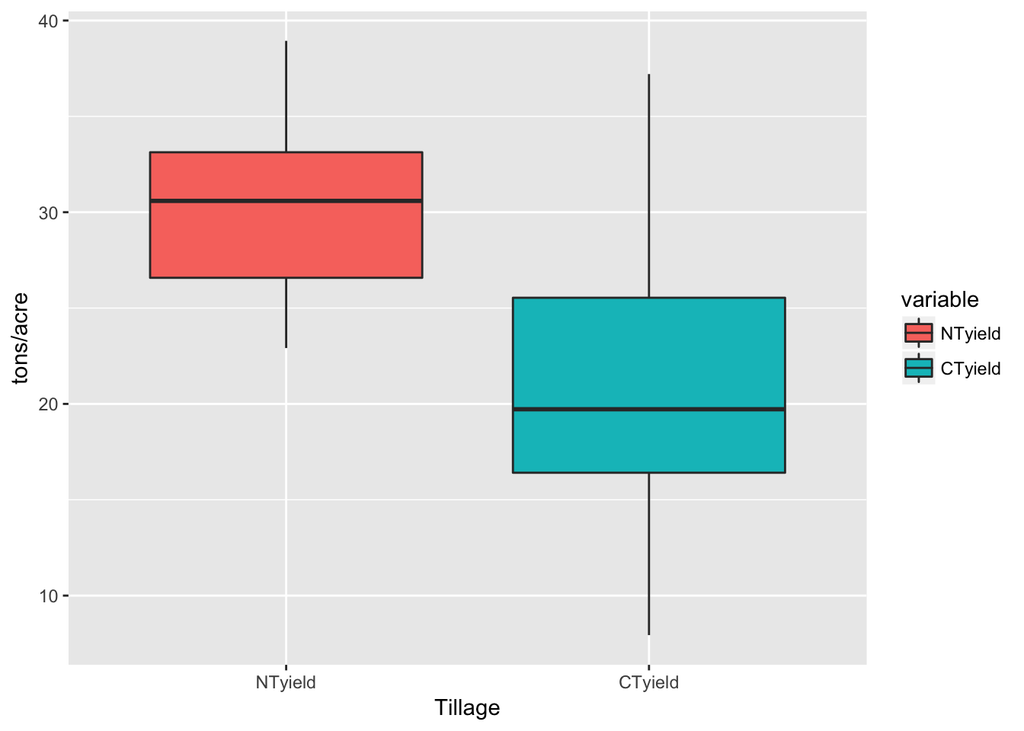

```r
########################################################
# FUNCTION: ANOfunPlot
# plots anova created previously
# input: DataFun (created in first function)
# output: boxplot comparing NT versus CT crop yields
#-------------------------------------------------------
ANOfunPlot <- function(data=DataFun){
  ggdata <- ggplot(data=data,
                   aes(x=variable,y=value,fill=variable)) + geom_boxplot() + xlab("Tillage") + ylab("tons/acre")
  print(ggdata)
}
ANOfunPlot()
```

2. Once your code is up and working, modify your program do something else: record a new summary variable, code a new statistical analysis, or create a different set of random variables or output graph. Do not rewrite any of your existing functions. Instead, copy them, rename them, and then modify them to do new things. Once your new functions are written, add some more lines of program code, calling a mixture of your previous functions and your new functions to get te job done.

```r
# changing the mean and sample size in the first function to see how that effects the significance intervals
ANOVA2 <- dataCreate(n1=200,n2=200,m1=75,m2=52)
#running an ANOVA on the new simulated data
ANOfun(data=ANOVA2)
```

```
##              Df Sum Sq Mean Sq F value Pr(>F)
## variable      1  55109   55109    2919 <2e-16 ***
## Residuals   398   7515      19
## ---
## Signif. codes:  0 '***' 0.001 '**' 0.01 '*' 0.05 '.' 0.1 ' ' 1
```

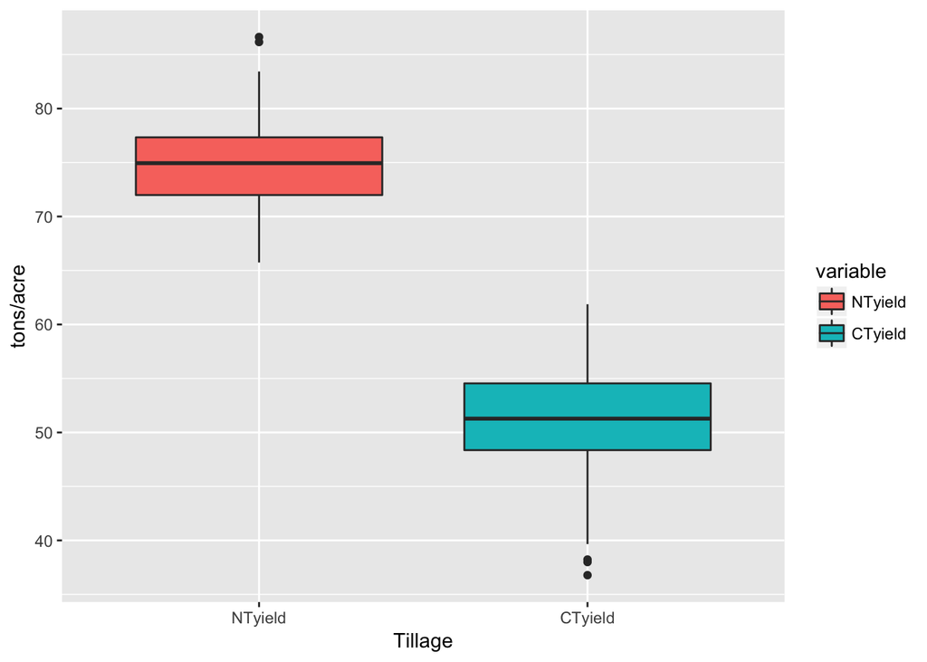

```r
# plotting new simulated data with a boxplot
ANOfunPlot(data=ANOVA2)
```